## Most harmful for people and economics natural disasters

### Synopsis

Data used in this analysis was obtained from NOAA storm database. The aim of the analysis was to understand what types of events are the most harmful in respect to human health and which of events have the greatest economic consequences. To assess impact on human health, two columns, which shows fatalities and injuries, were used to obtain the total amount of people affected by each type of the events. Results showed that tornadoes, storms and high temperature are the top-3 most common causes of human death or injury. Economic consequnces were analyzed based on property and crop damage. Main three type of events which influence economic mostly are storms, floods and tornadoes.

### Data Processing

Data was loaded from the bz2 archive, which contains csv file:

```r
download.file("http://d396qusza40orc.cloudfront.net/repdata%2Fdata%2FStormData.csv.bz2", destfile = "./repdata-data-StormData.csv.bz2")
data <- read.csv(bzfile("repdata-data-StormData.csv.bz2"))
```

From this only columns useful for this study were taken:

```r
usefuldata <- data[ , c("EVTYPE", "FATALITIES", "INJURIES", "PROPDMG",
                        "PROPDMGEXP", "CROPDMG", "CROPDMGEXP")]
str(usefuldata)
```

```
## 'data.frame':    902297 obs. of  7 variables:
##  $ EVTYPE    : Factor w/ 985 levels "   HIGH SURF ADVISORY",..: 834 834 834 834 834 834 834 834 834 834 ...
##  $ FATALITIES: num  0 0 0 0 0 0 0 0 1 0 ...
##  $ INJURIES  : num  15 0 2 2 2 6 1 0 14 0 ...
##  $ PROPDMG   : num  25 2.5 25 2.5 2.5 2.5 2.5 2.5 25 25 ...
##  $ PROPDMGEXP: Factor w/ 19 levels "","-","?","+",..: 17 17 17 17 17 17 17 17 17 17 ...
##  $ CROPDMG   : num  0 0 0 0 0 0 0 0 0 0 ...
##  $ CROPDMGEXP: Factor w/ 9 levels "","?","0","2",..: 1 1 1 1 1 1 1 1 1 1 ...
```

Columns PROPDMGEXP and CROPDMGEXP contains the power of 10 in form of letter (H, K, M, etc.). In order to transform them to the number new columns propmult and cropmult were added, containing value 10^x, where x = 2 for h or H, x = 3 for K, etc. For other symbols in PROPDMGEXP and CROPDMGEXP value 1 was assigned, since there was no exact rule on how to proceed in each case, and working them all out one at a time by hands is too time consuming and goes well beyond objectives of this course :)

Values from PROPDMG and CROPDMG columns were then modified by multiplying them by respective multiplier from propmult and cropmult:

```r
usefuldata$propmult <- 1
usefuldata$propmult[usefuldata$PROPDMGEXP == "h"] <- 100
usefuldata$propmult[usefuldata$PROPDMGEXP == "H"] <- 100
usefuldata$propmult[usefuldata$PROPDMGEXP == "K"] <- 1000
usefuldata$propmult[usefuldata$PROPDMGEXP == "M"] <- 1000000
usefuldata$propmult[usefuldata$PROPDMGEXP == "m"] <- 1000000
usefuldata$propmult[usefuldata$PROPDMGEXP == "B"] <- 1000000000

usefuldata$cropmult <- 1
usefuldata$cropmult[usefuldata$CROPDMGEXP == "h"] <- 100
usefuldata$cropmult[usefuldata$CROPDMGEXP == "H"] <- 100
usefuldata$cropmult[usefuldata$CROPDMGEXP == "K"] <- 1000
usefuldata$cropmult[usefuldata$CROPDMGEXP == "M"] <- 1000000
usefuldata$cropmult[usefuldata$CROPDMGEXP == "m"] <- 1000000
usefuldata$cropmult[usefuldata$CROPDMGEXP == "B"] <- 1000000000

usefuldata$PROPDMG <- usefuldata$PROPDMG*usefuldata$propmult
usefuldata$CROPDMG <- usefuldata$CROPDMG*usefuldata$cropmult
```

From resulting data set columns PROPDMGEXP, CROPDMGEXP, propmult and cropmult were excluded:

```r
usefuldata <- usefuldata[, -c(5, 7, 8, 9)]
```

In the next step entries from EVTYPE column were subjected to some cleaning. Specifically, all punctuation marks were deleted, and, afterwards entries were modified in order to fall into bigger groups. For example, all entries containing following patterns: WINTER, WINTR, FREEZ, COLD, ICE, GLAZE, SNOW, FROST - were renaimed simply as WINTER, since all of them occur only during winter season:

```r
usefuldata$EVTYPE <- gsub("[[:punct:]]", "", usefuldata$EVTYPE)
usefuldata$EVTYPE <- gsub(" ", "", usefuldata$EVTYPE)
usefuldata$EVTYPE <- toupper(usefuldata$EVTYPE)

x <- grep("SUMMARY", usefuldata$EVTYPE)
usefuldata <- usefuldata[-x, ]
x <- grep("TORNADO", usefuldata$EVTYPE)
usefuldata[x, "EVTYPE"] <- "TORNADO"
x <- grep("FLOOD|DROWN|FLASH|FLD", usefuldata$EVTYPE)
usefuldata[x, "EVTYPE"] <- "FLOOD"
x <- grep("HEAT|WARM|HOT", usefuldata$EVTYPE)
usefuldata[x, "EVTYPE"] <- "HIGHTEMP"
x <- grep("STORM|TSTM|WIND|HURRICANE|RAIN|HAIL|BLIZZARD|SPOUT|TYPHOON", usefuldata$EVTYPE)
usefuldata[x, "EVTYPE"] <- "STORM"
x <- grep("WINTER|WINTR|FREEZ|COLD|ICE|GLAZE|SNOW|FROST", usefuldata$EVTYPE)
usefuldata[x, "EVTYPE"] <- "WINTER"
x <- grep("FOG", usefuldata$EVTYPE)
usefuldata[x, "EVTYPE"] <- "FOG"
x <- grep("FIRE", usefuldata$EVTYPE)
usefuldata[x, "EVTYPE"] <- "FIRE"
x <- grep("RIPCURRENT", usefuldata$EVTYPE)
usefuldata[x, "EVTYPE"] <- "RIPCURRENT"
x <- grep("SURF|TSUNAMI|TIDE", usefuldata$EVTYPE)
usefuldata[x, "EVTYPE"] <- "SURF"
x <- grep("AVALANCHE", usefuldata$EVTYPE)
usefuldata[x, "EVTYPE"] <- "LANDSLIDE"
remove(x)
```

#### Harm to population health

In order to analyze harm to people’s health columns EVTYPE, FATALITIES and INJURIES were taken. Subsequently, this data was melted with melt() function from reshape2 package, putting data from FATALITIES and INJURIES column into one. To sum up the total amount of people affected by each type of event ddply() function from plyr package was used. Column renaiming was made for convenience.

```r
library(reshape2)
library(plyr)
health <- usefuldata[, 1:3]
melted <- melt(health, id.vars = "EVTYPE")
health <- ddply(melted, "EVTYPE", summarize, sum(value))
names(health) <- c("EVTYPE", "affected")
```

To represent only the most harmful events, minimal threshold for amount of people affected was set to be 50. Sorting was made in descending order with arrange() function from plyr package.

```r
health <- health[health$affected > 50,]
health <- arrange(health, desc(affected))
```

#### Harm to economics

Steps for damage analysis are as follows. First, columns EVTYPE, PROPDMG and CROPDMG were taken, values from the latter two were summed up forming new column DMG. After that columns PROPDMG and CROPDMG were removed.

```r
damage <- usefuldata[, c(1, 4, 5)]
damage$DMG <- damage$PROPDMG + damage$CROPDMG
damage <- damage[,c(1, 4)]
```

Ddply() function was applied to sum up damage produced by each type of events, columns renamed for convenience. Minimal threshold in this case was set to be 5000000 (five millions), and the sorting again was made in descending order.

```r
damage <- ddply(damage, "EVTYPE", summarize, sum(DMG))
names(damage) <- c("EVTYPE", "DMG")
damage <- damage[damage$DMG > 5000000,]
damage <- arrange(damage, desc(DMG))
```

### Results

Results for population harm are:

```r
health
```

```
##        EVTYPE affected
## 1     TORNADO    97068
## 2       STORM    21790
## 3    HIGHTEMP    12421
## 4       FLOOD    10237
## 5   LIGHTNING     6047
## 6      WINTER     2867
## 7        FIRE     1698
## 8         FOG     1156
## 9  RIPCURRENT     1106
## 10       SURF      566
## 11  LANDSLIDE      484
```

Graphical representation can be made either in a bar chart or a pie chart form. To draw a pie chart pie() function was used from graphics package

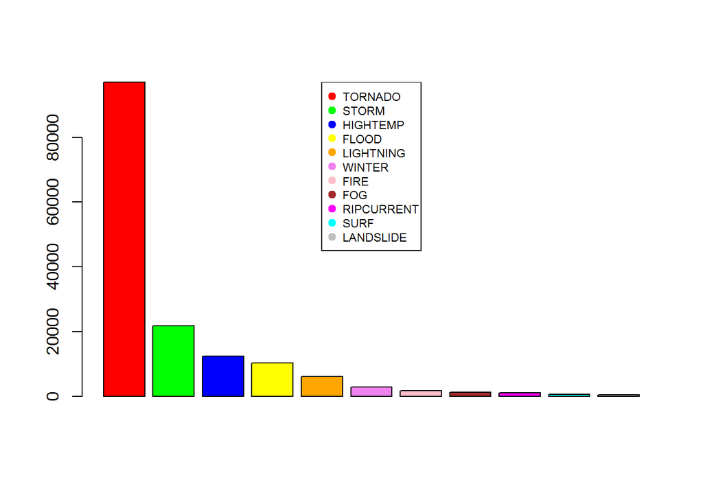

```r
barplot(health$affected, col = c("red", "green", "blue", "yellow",
                               "orange", "violet", "pink", "brown",
                               "magenta", "cyan", "grey"))
legend("top", health$EVTYPE, col = c("red", "green", "blue", "yellow",
                                   "orange", "violet", "pink", "brown",
                                   "magenta", "cyan", "grey"), cex=0.7, pch=19,
       pt.cex = 1)
```

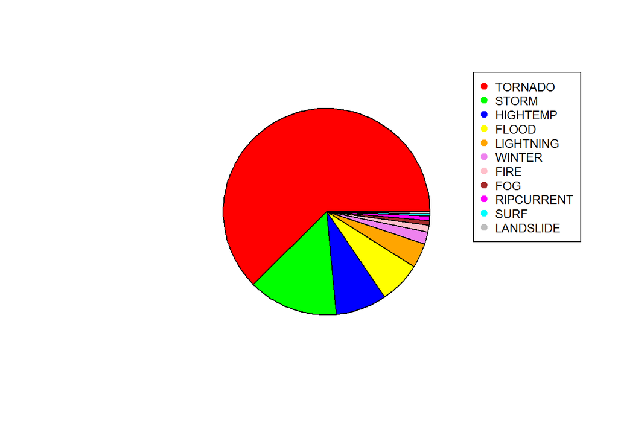

```r
pie(health$affected, labels = NA, col = c("red", "green", "blue", "yellow",
                                        "orange", "violet", "pink", "brown",
                                        "magenta", "cyan", "grey"))

legend("topright", health$EVTYPE, col = c("red", "green", "blue", "yellow",
                                        "orange", "violet", "pink", "brown",
                                        "magenta", "cyan", "grey"), cex=0.8,
       pch=19, pt.cex = 1)
```

Results for economics damage are:

```r
damage
```

```
##              EVTYPE       DMG
## 1             STORM 2.061e+11
## 2             FLOOD 1.800e+11
## 3           TORNADO 5.901e+10
## 4           DROUGHT 1.502e+10
## 5              FIRE 8.905e+09
## 6            WINTER 4.753e+09
## 7         LIGHTNING 9.408e+08
## 8          HIGHTEMP 9.248e+08
## 9         LANDSLIDE 3.483e+08
## 10             SURF 2.553e+08
## 11 EXCESSIVEWETNESS 1.420e+08
## 12              FOG 2.283e+07
## 13    DRYMICROBURST 6.748e+06
```

Both bar chart and pie chart can be used here as well. Bar chart was chosen.

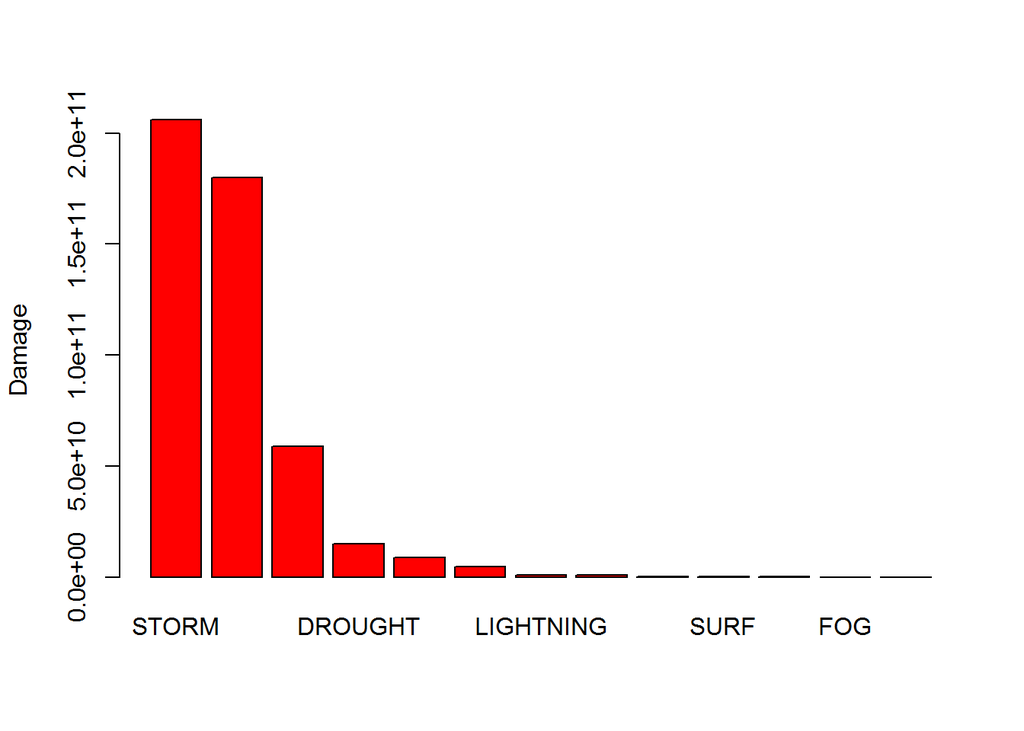

```r
barplot(damage$DMG, names.arg = damage$EVTYPE, ylab = "Damage",
        col = "red")
```